# R Módulo VI: Series de Tiempo

MIDE

12/12/2020

En esta sesión se harán algunos ejemplos de series de tiempo. Dada la extensión del tema, no es posible abarcar todos los temas posibles, por lo que revisaremos algunos temas en especial, y que fueron solicitados por algunos de los participantes.

En términos prácticos, una serie de tiempo se puede analizar con varios propósitos en mente. Nos interesa comprender el comportamiento de una variable $y_t$ a lo largo del tiempo, por ejemplo:

- para comprender sus fluctuaciones con respecto a un valor promedio, (variabilidad de la serie);
- para identificar tendencia y nivel de la serie,
- para proyectar su posible comportamiento hacia el futuro, generando pronósticos y predicciones útiles para la planeación y toma de decisiones;
- para tratar de encontrar un modelo matemático que explique el *proceso generador de los datos* así como su *comportamiento*, a través de si misma o de otros posibles *predictores*.

Un supuesto fundamental de las series de tiempo es que es factible que *el comportamiento pasado de una variable nos ayude a explicar su comportamiento actual o su comportamiento futuro*.

## Pronósticos y análisis de series temporales.

Es importante hacer notar que pronosticar y analizar una serie de tiempo son dos actividades distintas. Un pronóstico es una visión de un futuro incierto, mientras que analizar una serie de tiempo es describir el proceso generador de los datos. Podemos analizar una serie de tiempo sin considerar como objetivo hacer pronósticos, así como podemos hacer pronósticos sin pensar en series de tiempo (o de hecho cualquier otro tipo de análisis).

Los principales precursores de la actividad de pronóstico son la construcción de un modelo adecuado basado en el desarrollo histórico de la serie y la utilización de información relevante al posible desarrollo futuro de la serie.

## Descomposición de series de tiempo.

Una forma de modelar una serie de tiempo se obtiene al suponer que está conformada de diferentes componentes. Los componentes básicos son los siguientes:

- **Tendencia**: el movimiento hacia arriba o hacia abajo que caracteriza a una serie de tiempo en un periodo de tiempo dado. Muestra el crecimiento o decline de una serie en el largo plazo.
- **Estacionalidad**: es el comportamiento que muestra una serie a lo largo de un periodo de tiempo, típicamente un año, y que se repite durante varios periodos.
- **Ciclo**: se refiere a movimientos recurrentes hacia arriba o hacia abajo alrededor del nivel de tendencia. Usualmente son movimientos que se observan en periodos mayores a un año.
- **Error**: se refiere a la parte de la serie que es completamente aleatoria; es el error estadístico que se presenta por incertidumbre.

El método clásico de descomposición tiene el objetivo de separar los componentes de una serie de tiempo. Este método supone que una serie de tiempo se puede escribir como una función de tres componentes:

$$X_t= f(TC_t,S_t,E_t)$$

donde $f$ es una función que relaciona los componentes, $TC$ es un componente de tendencia-ciclo, $S$ es un componente estacional, $E$ es el componente de error o ruido de la serie.

El modelo puede ser multiplicativo o aditivo. Veamos un ejemplo.

```r
pasajeros <- c(112, 118 , 132 , 129 , 121 , 135 , 148 , 148 , 136 , 119 , 104 , 118,
115 , 126 , 141 , 135 , 125 , 149 , 170 , 170 , 158 , 133 , 114 , 140,
145 , 150 , 178 , 163 , 172 , 178 , 199 , 199 , 184 , 162 , 146 , 166,
171 , 180 , 193 , 181 , 183 , 218 , 230 , 242 , 209 , 191 , 172 , 194,
196 , 196 , 236 , 235 , 229 , 243 , 264 , 272 , 237 , 211 , 180 , 201,
204 , 188 , 235 , 227 , 234 , 264 , 302 , 293 , 259 , 229 , 203 , 229,
242 , 233 , 267 , 269 , 270 , 315 , 364 , 347 , 312 , 274 , 237 , 278,
284 , 277 , 317 , 313 , 318 , 374 , 413 , 405 , 355 , 306 , 271 , 306)

(n <- length(pasajeros))  #número de observaciones disponibles
```

```
[1] 96
```

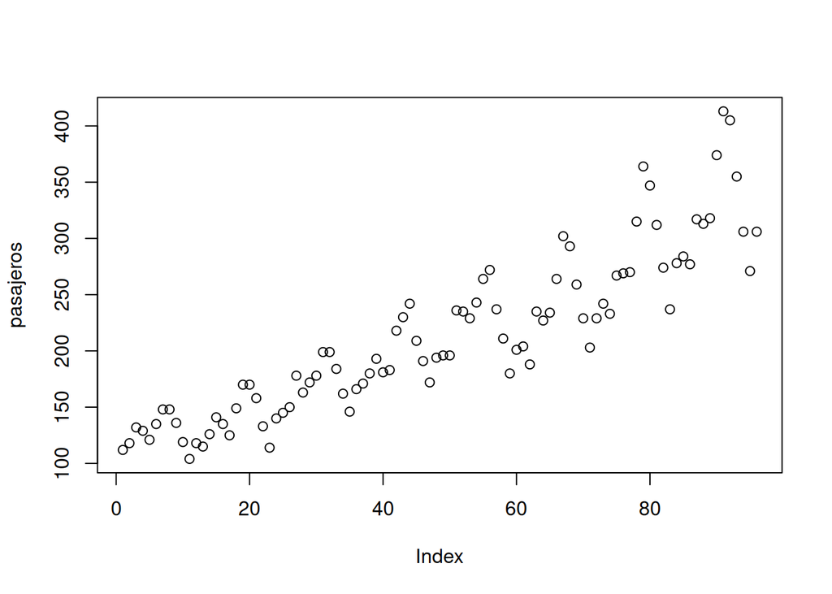

```r
plot(pasajeros)
```

```r
# Para dar formato a la serie de tiempo, usamos la función ts

(ts.pasajeros <- ts(data = pasajeros, start = c(1949,1), frequency = 12))
```

```
     Jan Feb Mar Apr May Jun Jul Aug Sep Oct Nov Dec
1949 112 118 132 129 121 135 148 148 136 119 104 118
1950 115 126 141 135 125 149 170 170 158 133 114 140
1951 145 150 178 163 172 178 199 199 184 162 146 166
1952 171 180 193 181 183 218 230 242 209 191 172 194
1953 196 196 236 235 229 243 264 272 237 211 180 201
1954 204 188 235 227 234 264 302 293 259 229 203 229
1955 242 233 267 269 270 315 364 347 312 274 237 278
1956 284 277 317 313 318 374 413 405 355 306 271 306
```

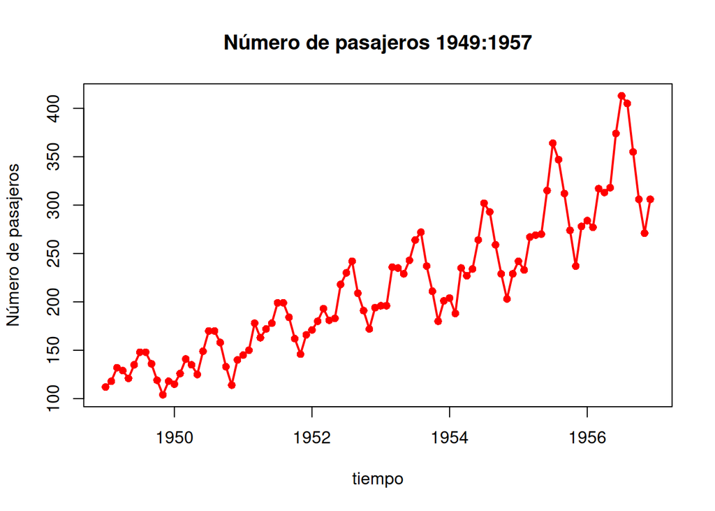

```r
plot(ts.pasajeros, main = "Número de pasajeros 1949:1957", type = "o", pch=16,
     col="red", lwd=2, xlab = "tiempo", ylab = "Número de pasajeros")
```

A través de hacer varios promedios se van teniendo los diferentes componentes de la serie. Aquí lo haremos directo con una sóla función:

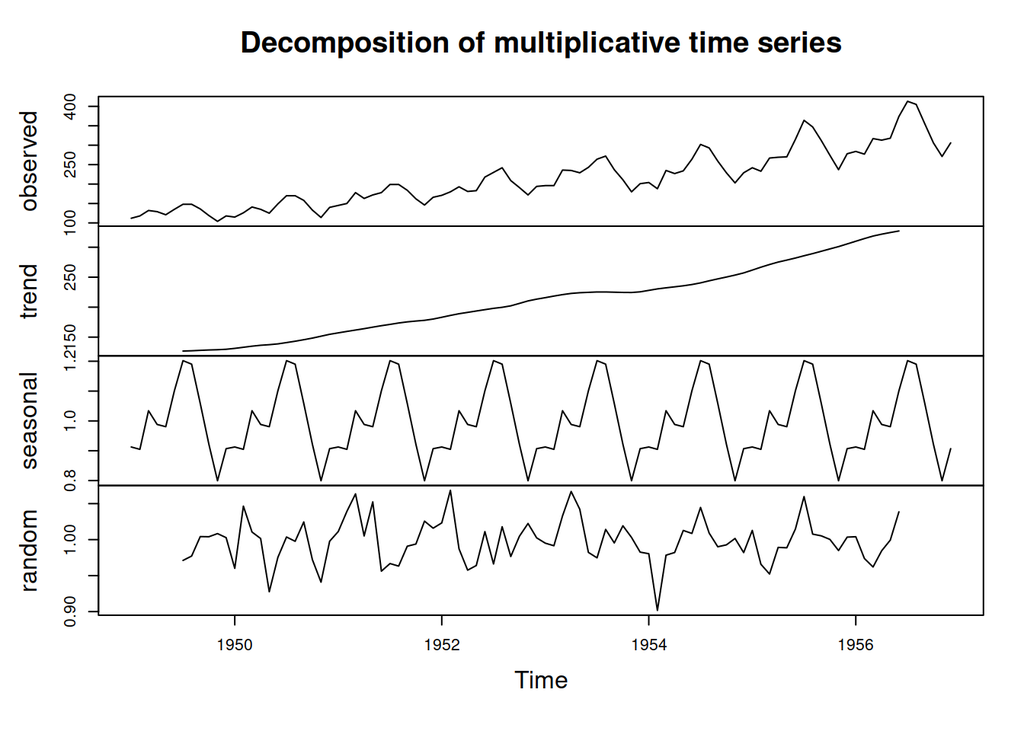

```r
m <- decompose(ts.pasajeros, type = "m")
plot(m)
```

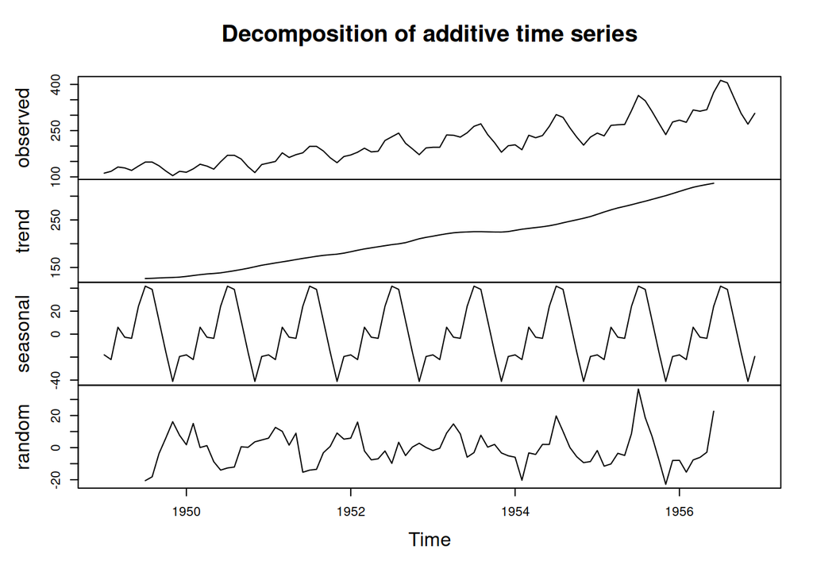

```r
a <- decompose(ts.pasajeros, type = "additive")
plot(a)
```

La ventaja de tener identificados los componentes de la serie es que ahora podemos pronosticar cada componente por separado.